# Perception réciproque entre cyclistes et automobilistes

KEBE Abdoulaye

25 Août 2020

# Lexique des abréviations

Bulletin d’Analyse des Accidents de la Circulation

Centre d’Etudes et d’expertise sur les Risques, l’environnement, la Mobilité et l’Aménagement.

Direstion Départementale de l’Agriculture et de la Forêt

Direction Départementale des Territoires et de la Mer

Enquête Ménages Déplacements

Fédération des Usagers de la Bicyclette

Institut Français des Sciences et Technologies des Transports, de l’Aménagement et des Réseaux.

Observatoire National Interministriel de la Sécurité Routière

# Introduction

Le plan “Vélo et mobilité active” du ministère de la transition écologique a été lancé en septembre 2018 avec un objectif ambitieux: tripler la part modale du vélo dans les déplacements au quotidien des individus passant de 3% à 9% en 2024. Toutefois, ce plan repose sur la sécurité routière et le confort des trajets à vélo afin d’encourager l’usage de ce dernier.

Au niveau du Calvados, la question de la sécurité routière pour les cyclistes se pose d’autant plus que 77% parmi eux ne se sentent pas en sécurité en circulation et ce, quelque soit le sexe, l’âge ou la zone de résidence (aire urbaine de Caen ou hors de cette aire).

Par ailleurs, l’insatisfaction des cyclistes en termes de sécurité routière est fortement liée au fait qu’ils se sentent exposés sur certains axes, notamment les ronds-points, les intersection et les routes départementales. Ce sentiment d’insécurité s’explique par divers facteurs.

Au niveau des rond-points et intersections, la principale cause d’insécurité est l’absence d’aménagements cyclables ou de marquage pour les cyclistes. Sur les routes départementales, la vitesse provoque un sentiment d’insécurité accentué par l’absence de séparation pysique entre cyclistes et automobilistes.

Par ailleurs, les automobilistes considèrent les cyclistes respectueux. Les principaux points de discorde entre cyclistes et automobilistes sont:

- les cyclistes qui se mettent au niveau des SAS vélo au feu rouge,
- les cyclistes brûlant les feux rouges,
- ceux qui n’empruntent pas les pistes cyclables “conseillées”" et les relentissent.

Ainsi, une sensibilisation des cyclistes à l’égard du code de la route et des automobilistes sur les droits des usagers du vélo s’avère nécessaire.

Outre, la perception réciproque entre cyclistes et automobilistes, l’étude accidentologique, portant sur les facteurs environtaux des accidents corporels impliquant un cycliste et recencés par le Bulletin d’Analyse des Accidents de la Circulation (BAAC), indique que les doubles-sens cyclables et la traversée de la chaussée restent des manoeuvres dangereuses pour les cyclistes.

Dans le cadre de cette étude, nous allons nous intéresser à la perception réciproque entre automobilistes et cyclistes. En d’autres termes, pour les cyclistes, il s’agit d’’étudier comment ils perçoivent les automobilistes vis à vis de leur sécurité dans la circulation et du confort de leur trajets. Pour les automobilistes,il s’agit de comprendre comment ils perçoivent les cyclistes en termes de courtoisie et de la qualité de leur partage de la chaussée avec ces derniers.

Pour ce faire, nous allons d’abord nous intéresser aux cyclistes, à leur sentiment de sécurité ou d’insécurité routière ainsi qu’à leur interaction avec les automobilistes. Ensuite, pour ces derniers, leur partage de la chaussée avec les cyclistes sera étudiée ainsi que leur perception du comportement de ces derniers à leur égard et à l’égard du code de la route.

# A- Contexte

En France métropolitaine, les cyclistes représentent 5.4% de la mortalité routière de l’année 2018, soit 175 cyclistes tués et 4328 blessés. Ainsi, le nombre de cyclistes tués sur la route a connu une hausse ces trois dernières années. C’est la seule catégorie d’usager pour laquelle le nombre de tués est en hausse par rapport à 2010, soit une hausse de 19% (ONISR, 2018). Or, ce mode de déplacement fait l’objet d’une politique publique portée par l’Etat et les collectivités, notamment à travers le Plan « Vélo et mobilité active ».

En effet, ce plan se fixe comme objectif de tripler la part modale du vélo dans les déplacements au quotidien d’ici 2024, en passant de 3 % à 9%. Ainsi, ce plan repose sur 4 axes :

- développer les aménagements cyclables et améliorer la sécurité routière ;
- mieux lutter contre les vols de vélo ;
- créer un cadre incitatif reconnaissant pleinement le vélo comme un moyen de déplacement vertueux (l’introduction du vélo dans le barème fiscal);
- et enfin développer une culture du vélo (développer le « reflexe vélo » dès le plus jeune âge).

Les enjeux liés à l’augmentation de la part modale du vélo sont d’ordre sanitaire, écologique et économique. En effet, l’usage du vélo contribue à diminuer le risque de maladies coronariennes, favorise la transition écologique et promeut la création d’emplois (dossier de presse plan vélo, septembre 2018). En outre, une forte présence de cyclistes dans la circulation favorise le phénomène de “Sécurité par le nombre”, diminuant ainsi le risque cycliste. D’autant plus qu’en 2018, il est estimé que le risque cycliste (le risque pour un cycliste d’être tué sur la route) au niveau national, est 3 fois plus élevé que pour les automobilistes pour une heure passée dans la circulation (ONISR, 2018).

Dans le cadre du plan vélo départemental, des initiatives ont été prises par le département du Calvados. Dans le cadre de ce plan, le Calvados a réalisé l’aménagement de 400 km de véloroutes. Ce qui constitue un premier réseau d’itinéraires cyclacles sur l’ensemble du territoire. Ce réseau est actuellement composé des axes suivants:

- la véloroute plage du Débarquement/Mont-Saint-Michel;
- la vélo Francette qui relie les 617 km entre La Rochelle et Ouistréham;
- la véloroute de l’Europe Centrale reliant sur 4000 km Kiev (en Ukraine) et Roscoff (en France). Cet axe traverse le Calvados (50% de la partie française s’y trouve) et est aujourd’hui aménagé à 92.6% et sa continuité sera assurée en 2021;
- l’axe la Seine à vélo qui relie les 390 km qui sépare Paris et la baie de la Seine (Le Havre en Seine Maritime et Deauville).

Face à cet engouement pour le vélo, la question de la sécurité et de l’accidentalité de ce moyen de déplacement mérite une attention particulière, en l’occurence dans le Calvados.

# B- L’accidentalité des cyclistes dans le Calvados

L’accidentalité des cyclistes dans le Calvados est étudiée sur la période 2014-2018. Une étude plus détaillée sera présentée par le Centre d’Etudes et d’expertise sur les Risques, l’Environnement, la Mobilité et l’Aménagement (CEREMA). Ainsi, sur cette période, 175 cyclistes sont impliqués dans un accident, dans le département du Calvados, pour un total de 173 accidents (BAAC). Ainsi, sur cette période, le département a connu une baisse du nombre d’accidents corporels impliquant un cycliste de l’ordre de 4%.

Les accidents corporels sont les accidents enregistrés par les forces de l’ordre dans le fichier BAAC. Dans ce dernier, un accident corporel de la circulation routière est tout accident qui:

- Implique au moins une victime
- Survient sur une voie publique ou privée ouverte à la circulation publique
- Implique au moins un véhicule.

Les véhicules motorisés quatre roues sont les plus impliqués dans les accidents des cyclistes. Ils représentent 77% des véhicules tiers impliqués contre 3% pour les deux roues motorisés.

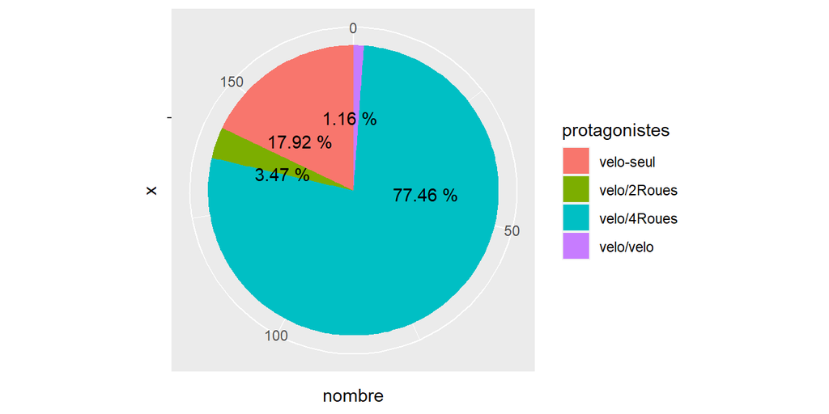

Par ailleurs, les accidents en agglomération sont les plus fréquents mais les moins mortels en raison de la vitesse moins élevée des véhicules tiers impliqués (ONISR, 2018). Le même constat peut être fait au niveau du département sur la période 2014-2018. Ainsi, sur les 12 morts enrengistrés, 9 sont tués hors-agglomération. Or, 65% des accidents ont eu lieu en agglomération.

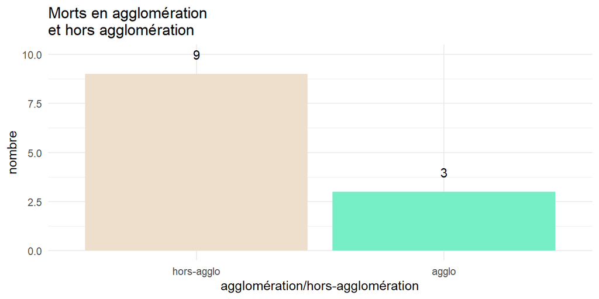

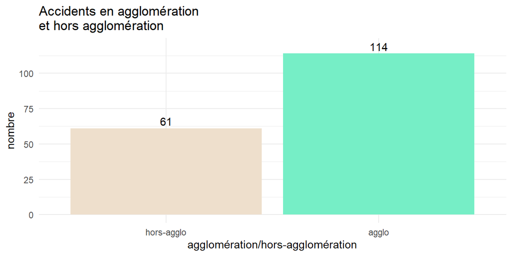

En plus du lieu, la gravité d’un accicdent dépend aussi du type de collision. Selon l’ONISR (2018), la moitié des accidents ayant occasionné une personne tuée ou blessée à bicyclette résultent d’une collision par le côté. Ce même constat peut être fait au niveau du Calvados,soit 41% des accidents mortels résultent d’une collision par le côté. Par ailleurs, la plupart des accidents des cyclistes implique un obstacle mobile en particulier les véhicules. La part des obstacles fixes (situés sur la chaussée ou sur le troittoir, noté ObsChausTrot) est relativement faible (8%).  
Néanmoins, Les véhicules en stationnement sont souvent les obstacles fixes heurtés par les cyclistes. En outre, la plupart des accidents corporels des cyclistes ont eu lieu en plein jour.

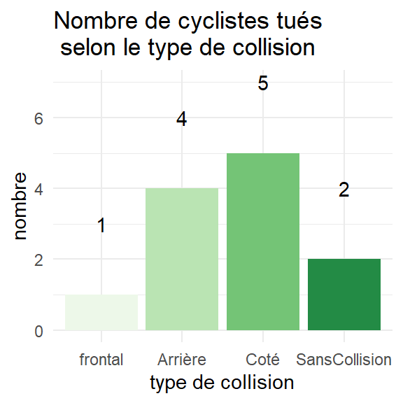

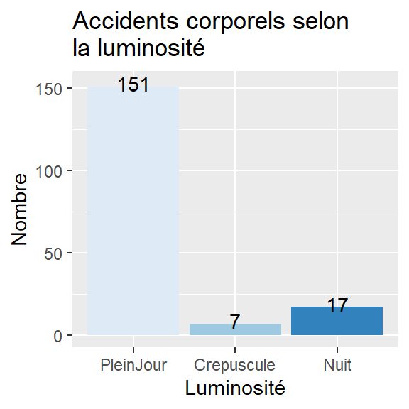

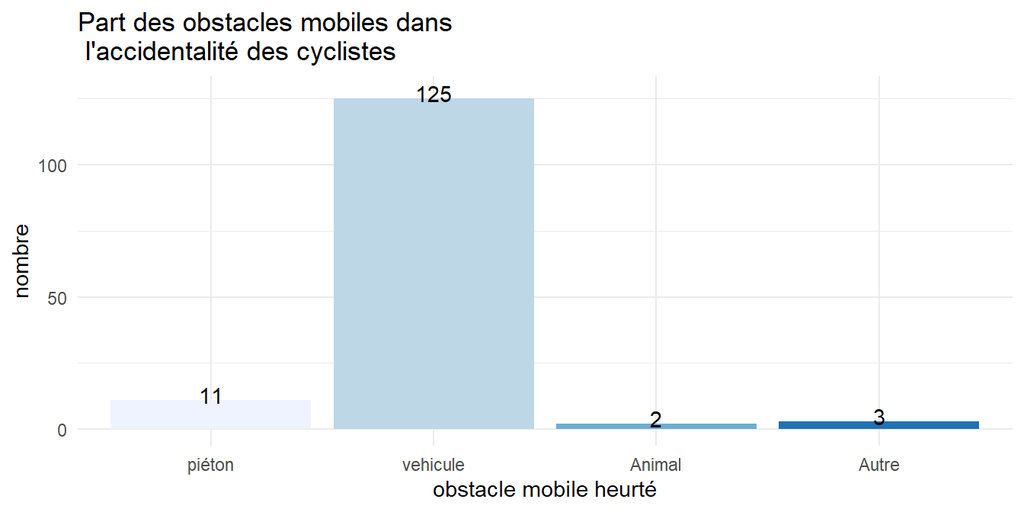

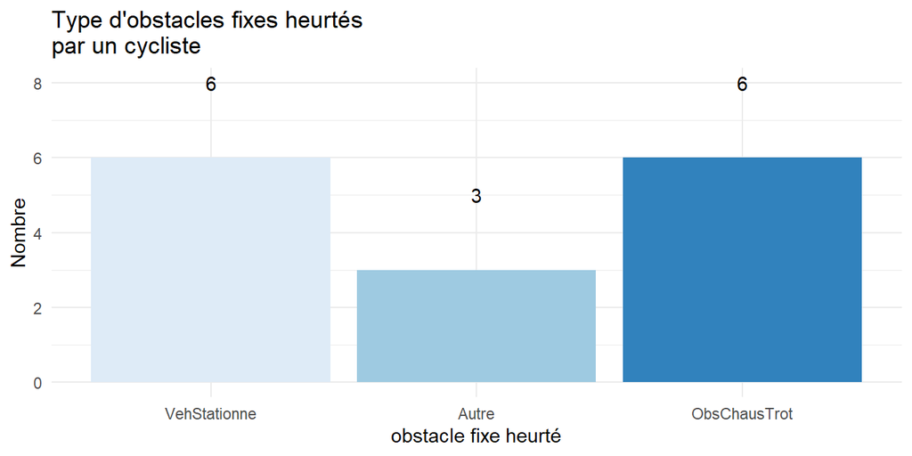

D’importantes disparités selon l’âge et le sexe sont à constater. En effet, les cyclistes hommes sont plus touchés par les accidents, de même que les personnes âgées de plus 45 ans.

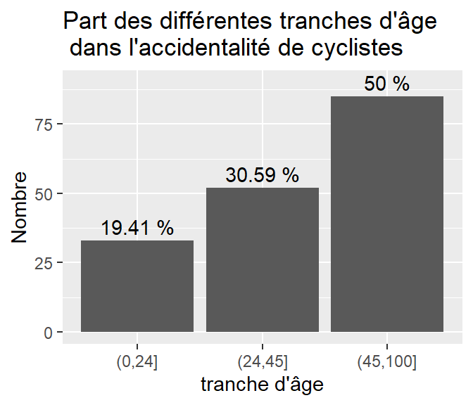

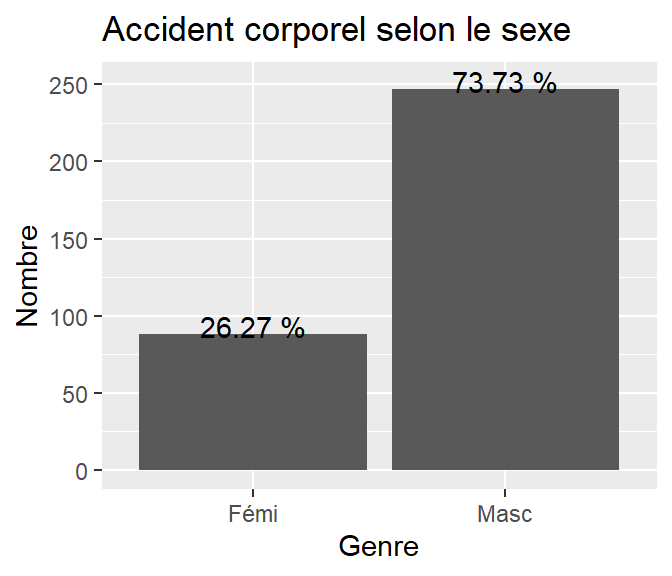

Par ailleurs, des disparités sont à noter selon les mois de l’année. Au niveau national, 62% des cyclistes tués ou blessés le sont entre avril et septembre (ONISR, 2018). Dans le département du Calvdos, 61% des accidents corporels de cyclistes ont eu lieu entre avril et septembre.

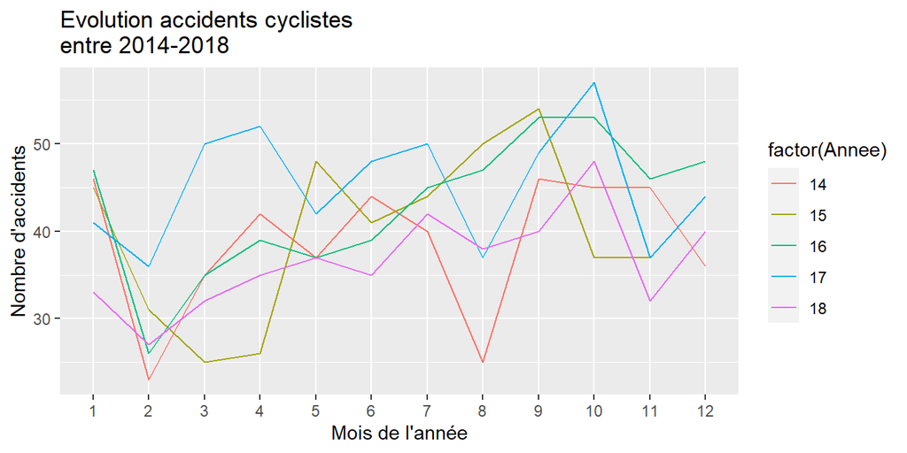

Outre les facteurs environnementaux (lieu, moment de la journée) les accidents des cyclistes sont aussi causés par des facteurs comportementaux. Il s’agit notamment des manoeuvres ayant précedé l’accident.

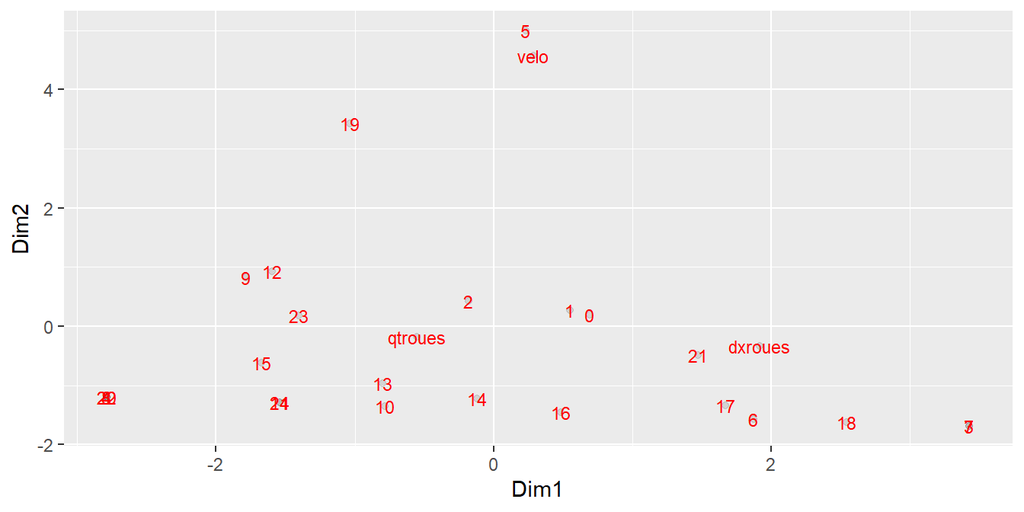

# C- Problématique et hypothèses de recherche

Il ressort de l’analyse d’accidentalité routière que les véhicules quatre roues sont les plus associés à l’accidentalité des cyclistes. Toutefois, ce résultat mérite d’être nuancés.

En effet, selon une étude de l’Ifsttar (2012) sur les données des hôpitaux (notamment le registre de Rhône), le nombre de blessés enregistrés par le BAAC est 4 fois inférieur au nombre réel enregistré par les hôpitaux et le nombre des blessés hospitalisés est deux fois supérieur aux données enregistrées dans le fichier BAAC. Ce décalage s’accentue davantage quand il s’agit d’un cycliste: les cyclistes ont une probabilité (égale à 34%) d’être enregistrés dans les données des forces de l’ordre inférieure à celle des autres usagers à gravité égale, et cette probabilité est encore plus faible lorsqu’il n’y a pas de tiers (2%) (Amoros 2007). En outre, Dans 70 % des cas, le cycliste chute seul (Alice Billot-Grasset, 2015) et seulement 30% implique un autre usager.

Néanmoins, le rapport entre cyclistes et automobilistes mérite une attention particulière dans l’optique d’accroître la part modale du vélo dans les déplacements. En effet, selon une étude menée par la Fédération des Usagers de le Bicyclette (FUB) en 2017 au niveau national, la majorité des répondants estimaient que les conditions de circulation à vélo ne sont pas satisfaisantes et 90% parmi eux estiment que les vélos restent dangereux pour les enfants et personnes âgées et seulement 8% estiment être respectés par les automobilistes. Ce constat sucite les questions suivantes:

- Le sentiment d’insécurité chez les cyclistes est-il un sentiment général ou dépend t-il de certaines caractéristiques du cycliste.
- Quels sont les faits et gestes des automobilistes que les cyclistes considèrent comme irrespectueux? Sont-ils déterminants?
- Existe t-il chez les cyclistes des comportements susceptibles d’amener les automobilistes à les mettre en danger ou à être irrespectueux?

Cette étude repose sur les hyposthèses suivantes: le comportement dangereux ou irrespectueux des usagers résulte

- d’une part, d’une ignorance des nouveautés du code de la route;
- et d’autre part, d’un manque de sensibilisation des usagers sur l’esprit de partage de la chaussée.

# D- Méthodologie et administration des questionnaires

Dans le cadre de cette étude, nous allons particulièrement nous intéresser à la perception réciproque entre les automobilistes et les cyclistes. Ainsi, deux questionnaires sont conçus: un destiné aux automobilistes et un autre destiné aux cyclistes. Les questions vont porter sur les aspects suivants:

- le confort: il s’agit de comprendre comment les usagers perçoivent le partage de certains aménagements avec d’autres usagers;
- la sécurité: Ces questions permettront de mesurer à quel point les mesures de sécurité sont respectées par un type d’usager et si elles ne sont pas respectées, qu’est ce que cela suscite chez l’autre usager;
- Connaissance du code de la route: A travers ces questions, l’objectif est d’évaluer à quel point les usagers enquêtés sont au courant des nouveautés du code de la route.

### Le questionnaire qualitatif

. A l’image du focus groupe, ce questionnaire permettra d’explorer la question de la sécurité routière et de la perception réciproque entre les usagers en question. Le questionnaire qualitatif a été conçu et mis en ligne avec Framaforms et est composé des questions suivantes:

- Question 1 : Vous sentez-vous en sécurité sur les aménagements cyclables que vous empruntez ?
- Question 2: En tant que cycliste, quels sont les aménagements routiers sur lesquels vous ne vous sentez pas en sécurité (intersection, rond-point, type de voies…) ?
- Question 3 : Sur ces endroits sensibles en termes de sécurité quels sont les comportements dangereux que vous avez pu identifier ?
- Question 4 : Pour vous, quelles sont les manœuvres des autres usagers qui vous mettent en danger dans la circulation ou vous font peur ?
- Question 5 : Lorsque vous circulez en vélo, avez-vous déjà entendu des remarques désobligeantes du type « moi je travaille… » ? Quelles sont ces remarques et dans quel contexte cela s’est-il produit ?
- Question 6: Si oui, dans votre cas, quels sont souvent les facteurs déclencheurs de ces conflits ?
- Question 7 : En tant qu’usager d’un véhicule motorisé, vous arrive t’il qu’un cycliste vous fasse peur de par son comportement ?
- Question 8 : En tant qu’automobiliste, est ce qu’un cycliste vous a déjà fait des remarques désobligeantes ? Quelles sont ces remarques et dans quel contexte cela s’est-il produit ?
- Question 9 : En tant qu’automobiliste, quelles sont les évolutions récentes du code de la route dont vous êtes au courant concernant les cyclistes ?
- Question 10 : Veuillez laisser un commentaire (ou suggestions) sur la sécurité routière et le vivre ensemble (voiture / vélo) dans la circulation ?

L’analyse complète de ce questionnaire est disponible dans l’annexe de ce document et le verbatim de ce questionnaire est disponible sur le lien https://layekebe.shinyapps.io/kebedashboard/.

Ainsi, à partir des réponses à ces questions, le questionnaire quantitatif est élaboré.

### Le questionnaire quantitatif: méthodologie

Cet effectif a été calculé en reprenant la part modale du vélo dans les déplacements au quotidien. Ainsi, nous supposons que la part modale du vélo au niveau national est identique à celle au niveau du Calvados. Par conséquent, la proportion de cyclistes utilisant le vélo au quotidien représente 3% des calvadosiens avec une marge d’erreur de 3%.

Ensuite, pour chacun de ces usagers, l’échantillon est subdivisé en croisant le sexe avec la zone d’habitation. Les zones d’habitation sont: l’aire urbaine de Caen et la zone situé hors de cette aire. Selon l’INSEE, l’aire urbaine de Caen représente 60% de la population du Calvados.

La notion d’aire repose sur celle d’unité urbaine. En effet, outre les critères morphologiques (continuité du bâti) et démographiques (aille minimale), des critères de fonctionnement tels que le nombre d’emploi et le déplacements domicile-travail sont utilisés. Ainsi, selon l’INSEE, l’aire urbaine se définit comme un ensemble continu et sans enclave formé par un pôle urbain (unité urbaine offrant plus de 10.000 emplois) et par sa couronne périurbaine, c’est-à-dire les communes dont 40% de la population active résidente ayant un emploi travaille dans le pôle urbain ou dans une communes fortement attirée par celui-ci; ces communes sont dites monopolarsées. L’aire urbaine de Caen est composée de 223 communes.

Ainsi, tant pour les cyclistes que les automobilistes, 60% des enquêtés habitent dans l’aire urbaine et les 40% résident en dehors de cette zone. En outre, pour chaque type d’usagers, l’effectif sera réparti suivant le sexe des répondants. Selon le dossier complet de l’INSEE 2017, la répartition de la population du département selon la zone d’habitation et le sexe est le suivant.

|  | homme | femme |
| --- | --- | --- |
| hors-aire urbaine | 48% | 52% |
| aire urbaine | 47% | 53% |

Ces proportions ont été calculées en enlevant la part de la population âge entre 0 et 15ans. En d’autres termes, la population enquêtées sont les habitants du Calvados âgés de plus de 15 ans.

### Les partenaires à cette enquête

Ainsi, dans le cadre de cette enquête, nous avons travaillé avec des associations telles que,“Dérailleurs” de Caen, Toutenvélo, la maison du vélo de Caen. En outre, d’autres établissements publics ont été partenaires de cette étude, notamment l’Agence d’Urbanisme de Caen Normandie Métropole (Aucame), Direction des Transports de Caen-la-Mer, le département du Calvados et Bayeux Intercom. Ces différents partenaires ont contribué à la diffusion du questionnaire en ligne.

### administration du questionnaire quantitatif

L’administration du questionnaire quantitatif s’est déroulée en deux étapes: une première enquête sur le terrain qui est un test du premier questionnaire élaboré et une deuxième, qui est l’administration du questionnaire définitif.

L’enquête de terrain test a mis permis de corriger le questionnaire initial en tenant en compte les remarques suivantes des enquêtés:

- la longueur du questionnaire,
- la similarité entre certaines questions,
- la reformulation de certaines questions

Le questionnaire quantitatif (définitif) est administré en utilisant deux méthodes: il est mis en ligne sur les sites des services de l’Etat dans le Calvados où il est accessible au grand public et sur la page d’accueil de partenaires à l’étude, tels que “Dérailleurs” de Bayeux, Byaeux Intercom, AUCAME.

Cependant, outre l’administration en ligne du questionnaire, des enquêtes de terrain ont été menées. L’enquête de terrain a été menée afin d’éviter d’avoir une seule catégorie de répondant, ce qui constituerait un biais. En effet, avec un unique questionnaire en ligne, seulement les cyclistes membres d’une association ou qui ont une tendance à consulter les sites où est publié le questionnaire auront la possibilité de répondre. Les enquêtes se sont déroulées essentiellement au centre ville de Caen, notamment à la place Saint Pierre, la place de Pierre Bouchard et au niveau de la Prairie en interrogeant les passants.

Comme pour le questionnaire qualitatif, la mise en ligne du questionnaire quantitatif est effectué avec Framaforms.

Les enquêteurs étaient des volontaires composés du personnel de la DDTM ou des autres établissEments partenaires. Les enquêtes ont été ménées dans un contexte de Covid-19. Ainsi, les enquêteurs ont été équipés de masques, en plus des gilets fluorescents.

Pour ce qui est de la logistique, les déplacements sur les lieux d’enquête ont été faits en utilisant les vélos mis à disposition par la DDTM.

# E- Données du questionnaire quantitatif

L’enquête quantitative s’est déroulée du 15/06/20 au 15/07/20.L’administration du questionnaire est faite tant en ligne que sur le terrain. L’échantillonnage a été effectué en croisant la zone d’habitation avec le sexe. Deux zones ont été considérées: l’aire urbaine de Caen et la zone hors aire urbaine de Caen.

Pour les cyclistes, les résultats se résument dans le tableau suivant:

|  | Femme | Homme |
| --- | --- | --- |
| hors aire urbaine | 20 | 24 |
| aire urbaine | 63 | 87 |

Par ailleurs,l’objectif en termes d’effectif se résume dans le tableau suivant:

|  | femme | homme |
| --- | --- | --- |
| hors aire urbaine | 26 | 24 |
| aire urbaine | 39 | 35 |

Ainsi, en zone urbaine, le nombre d’hommes et de femmes obtenu dépasse l’objectif de départ avec respectivement 52 et 24 individus de plus. Par contre, en zone hors aire urbaine, le nombre d’hommes souhaité est obtenu alors que 6 femmes cyclistes n’ont pas pu répondre au questionnaire, comme le montre le tableau suivant:

|  | Femme | Homme |
| --- | --- | --- |
| hors aire urbaine | -6 | 0 |
| aire urbaine | 24 | 52 |

Après suppression aléatoire des effectifs en excès, on obtient le tableau suivant:

|  | Femme | Homme |
| --- | --- | --- |
| hors aire urbaine | 20 | 24 |
| aire urbaine | 39 | 35 |

Etant donné que les femmes en zone hors urbaine sont sous représentées, un test chi est effectué afin de savoir s’il est nécessaire de procéder à un redressement des données. L’hypothèse nulle de ce test est: l’échantillon est généré par un processus aléatoire. Autrement dit, les deux critères d’échantillonnage sont indépendants l’un de l’autre.

```
##
##  Pearson's Chi-squared test with Yates' continuity correction
##
## data:  c_tab
## X-squared = 0.32617, df = 1, p-value = 0.5679
```

La p-valeur du test étant supérieure à 0,05, l’hypothèse nulle est acceptée. Ainsi, un redressement des données n’est pas nécessaire.

Pour les automobilistes, les résultats de l’enquête se résument ainsi:

|  | Femme | Homme |
| --- | --- | --- |
| hors aire urbaine | 36 | 43 |
| aire urbaine | 89 | 109 |

Les objectifs en termes de représentativité sont les suivants:

|  | femme | homme |
| --- | --- | --- |
| hors aire urbaine | 47 | 43 |
| aire urbaine | 72 | 64 |

Idem pour les cyclistes, l’objectif de représentivité des hommes en zone hors aire urbaine est réalisé, alors que pour les femmes, il manque 11 femmes. Par contre en zone urbaine les individus de plus sont au nombre de 17 et 45 respectivement pour les femmes et les hommes.

|  | Femme | Homme |
| --- | --- | --- |
| hors aire urbaine | -11 | 0 |
| aire urbaine | 17 | 45 |

Les femmes automobilistes hors zone urbaine sont sous représentées. Toutesfois, le test de chi-deux ci-dessous indique qu’un redressement des effectifs ne sera pas nécessaire: la p-valeur du test étant supérieure à 0,05.

```
##
##  Pearson's Chi-squared test with Yates' continuity correction
##
## data:  a_tab
## X-squared = 1.0297e-30, df = 1, p-value = 1
```

La suppression aléatoire des individus de plus donne la table suivante:

|  | Femme | Homme |
| --- | --- | --- |
| hors aire urbaine | 36 | 43 |
| aire urbaine | 72 | 64 |

# I- Présentation de la DDTM

La Direction Départementale des Territoires et de la Mer (DDTM) est un service déconcentré de l’État français prenant la forme d’une direction départementale interministérielle, placée sous l’autorité du préfet du département, mais dépendant hiérarchiquement des Services du Ministre de l’Intérieur. Elle a été créée depuis le 1er janvier 2010. Les missions de cette direction touche plusieurs secteurs notamment l’environnement, l’urbanisme et l’agriculture. En effet, la direction résulte de la fusion de plusieurs services que sont:

- la Direction Départementale de l’Agriculture et de la Forêt (DDAF),
- la direction départementale de l’équipement,
- le service environnement de la préfecture,
- le service eau et riques et la Direction des Affaires Maritimes (pour les départements du littoral).

Ainsi, la DDTM intervient dans des domaines variés concernant l’aménagement durable des territoires:

- l’aménagement urbain et le logement,
- l’agriculture et les espaces ruraux,
- les espaces naturels et littoraux,
- la prévention des risques,
- le milieu marin et les activités maritimes.

Le stage s’est déroulé au sein de la DDTM du Calvados, située à 10 Boulevard Général Vanier à Caen, dans l’unité sécurité routière du Service du Système d’Information, de la Circulation routière et de l’Expertise Territoriale (SSICRET). L’unité de la sécurité routière a pour mission:

- de porter la politique locale de sécurité routière en interne et en externe à la DDTM,
- de diffuser la connaissance de l’insécurité routière dans les instances,
- d’instruire et de coordonner pour le compte de l’Etat la règlementation en matière de circulation routière (dérogations poids lourds, avis sur arrêtés de police sur les routes à grandes circulation, épreuves sportives),
- d’instruire les demandes de transports exceptionnels.

Afin de mener à bien ses missions, l’unité est composée de quatre agents. Outre, le responsable de l’unité, il s’agit de:

- deux chargés d’études sécurité routière (catégorie B+). Ils sont chargés de produire des analyses dans le domaine et d’instruire des dossiers,
- un instructeur des transports exceptionnels (catégorie B),
- un assistant sécurité routière (catégorie C).

# II- Analyse de la perception des cyclistes

La perception des cyclistes est analysée en termes de sécurité routière, de confort des trajets et de la courtoisie des autres usagers (en l’occurence les automobilistes).

## a- Sécurité routière

Dans l’optique de tripler la part modale du vélo, le sentiment de sécurité routière des cyclistes est incontournable. Ainsi, il importe de mieux comprendre les déterminants de ce sentiment.

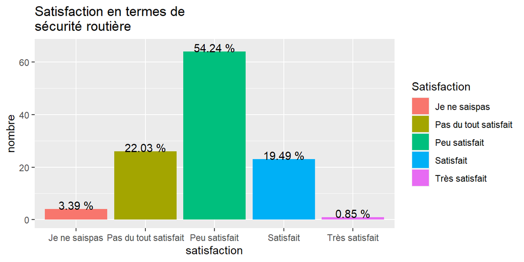

Par ailleurs, il est intéressant d’étudier le sentiment de sécurité ou d’insécurité selon le lieu d’habitation, le sexe et l’âge.

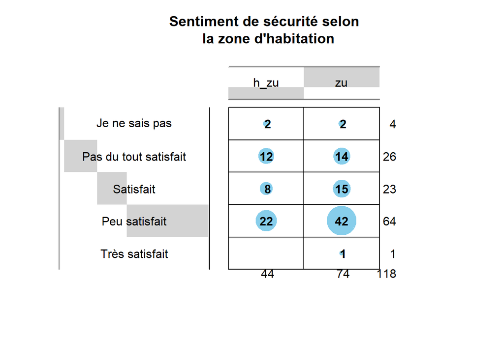

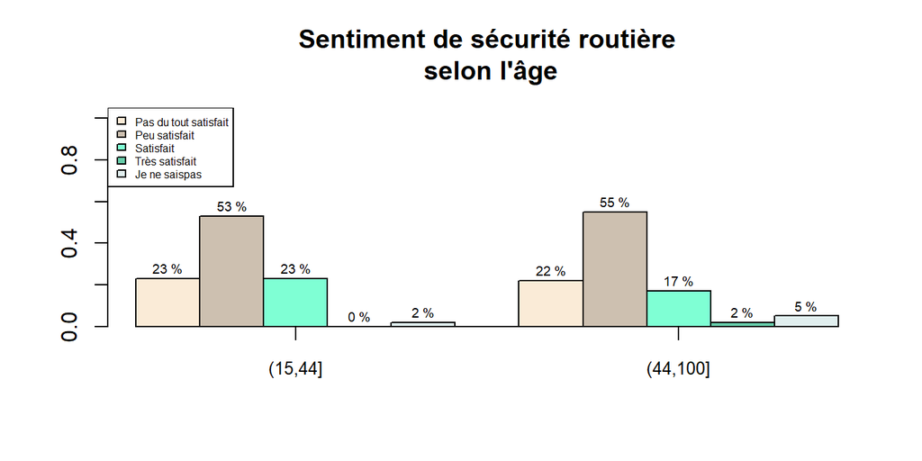

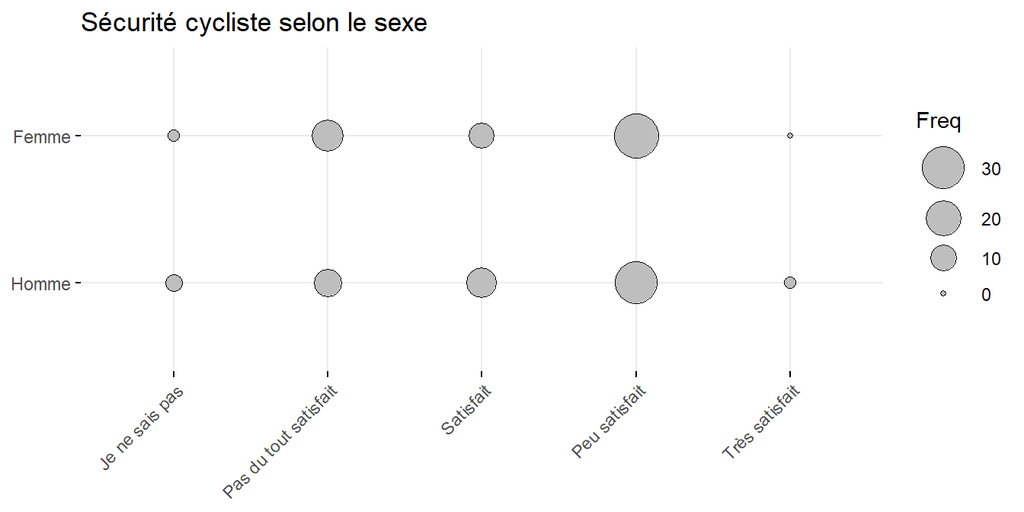

Des disparités sont observées dans les taux d’insatisfaction entre les hommes et les femmes. En effet, 70% des hommes estiment non satisfaisante leur situation sécuritaire sur la route contre 85% chez les femmes.

Dans ce qui suit, nous allons analyser le degré de dépendance entre le sentiment d’insécurité ou de sécurité et la zone d’habitation, l’âge et le sexe.

| VCramer | variable |
| --- | --- |
| 0.0195553 | satisfaction-zone |
| 0.0304898 | satisfaction-age |
| 0.1052690 | satisfaction-sexe |

Dans le tableau ci-dessus, la colonne nommée VCramer donne les valeurs issues du test de Cramer. Ce dernier a pour objectif de déterminer l’intensité d’une éventuelles relation entre deux variables qualitatives. La colonne variable donne les variables dont la relation est étudiée. Ainsi, ce tableau indique que l’intensité de la relation du sentiment d’insécurité avec chacune de ces variables, notamment, la zone de résidence, l’âge et le sexe sont inexistantes: Pour chacune des relations étudiées, le V de Cramer est inférieur à 0,20, qui est le seuil minimum pour qu’il existe une corrélation entre les variables.

Ainsi, nous pouvons conclure que le sentiment d’insécurité sur la route est un sentiment général chez les cyclistes et ne dépend pas de la zone d’habitation, ni de l’âge ou le sexe.

Le sentiment d’insécurité des cyclistes peut être expliqué par le type d’axe emprunté par ces derniers lors de leurs trajets. Les types d’axes pour lesquels nous allons nous intéresser sont: les ronds-points, les intersections et les routes départementales.

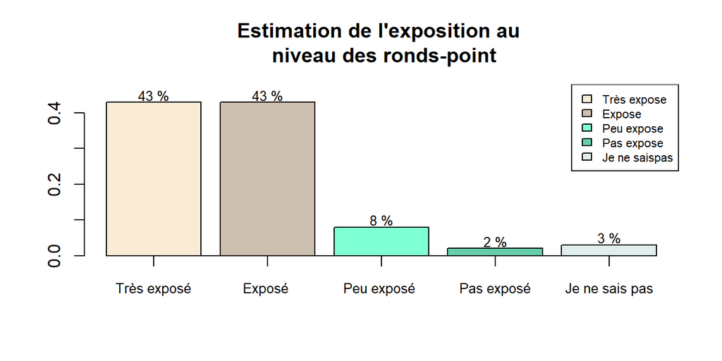

Le sentiment d’exposition est de 86% chez les cyclistes (somme des modalités “très exposé” et “exposé”) au niveau des ronds-points. Ce sentiment se répartit comme suit selon la satisfaction globale en termes de sécurité routière.

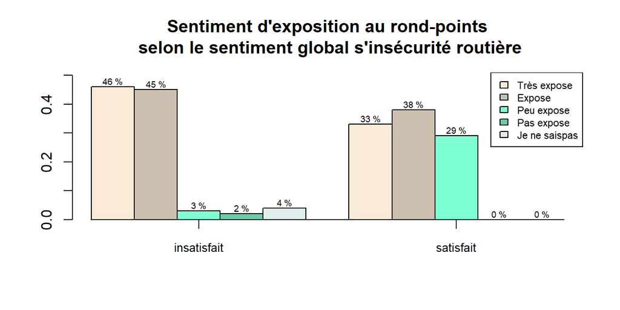

Selon le sentiment global d’insécurité, l’exposition au rond-point diffère. 70% des cyclistes qui sont satisfaits de leur sécurité sur la route pensent être quand même être exposés au niveau des ronds-points contre 90% pour ceux qui estiment insatisfaisante leur situation sécuritaire sur la route. Ce qui laisse présager que l’exposition au rond-point est déterminante dans le sentiment global de sécurité ou d’insécurité routière.

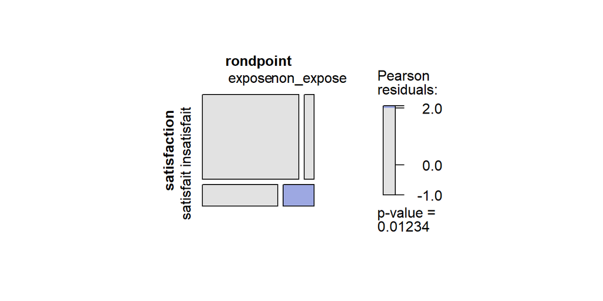

La figure ci-dessus indique que le sentiment de non exposition aux ronds-points est significativement associé au sentiment global de sécurité sur la route. Ainsi, les cyclistes qui se sentent moins exposés au niveau des ronds-points ont tendance à être satisfaits de leur sécurité routière dans l’ensemble.

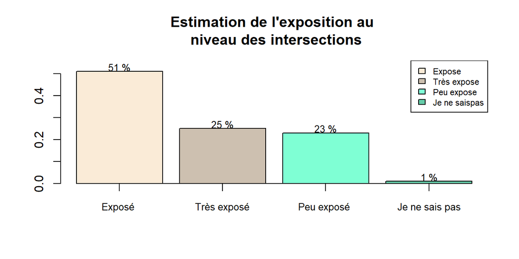

Le sentiment d’exposition au niveau des intersections est de 76% contre 86% au niveau des rond-points. Ainsi, le sentiment d’exposition au niveau des ronds-points serait-il significativement associé au sentiment d’insécurté chez les cyclistes?

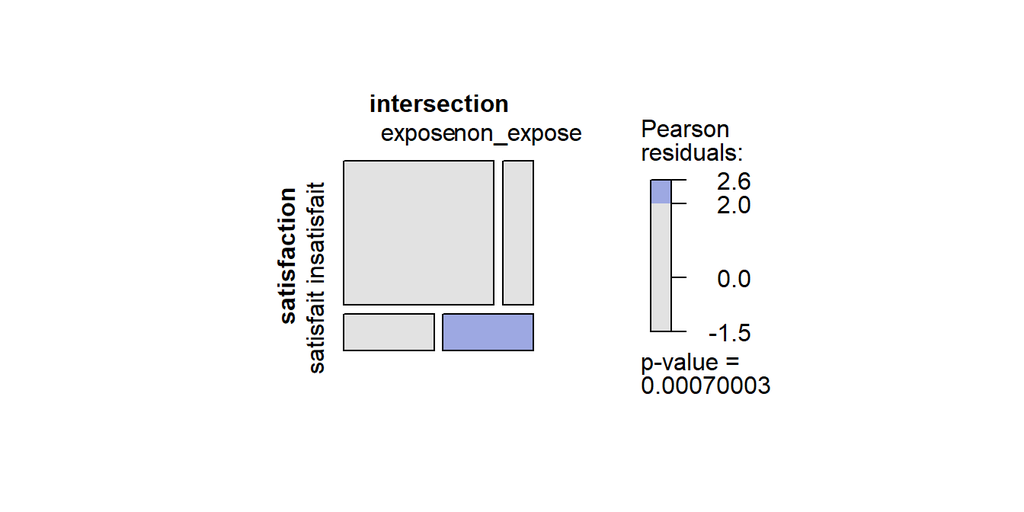

Comme pour la non exposition au niveau des rond-point, celle au niveau des intersection est aussi très significativement associée au sentiment de sécurité chez les cyclistes. Ce lien est surtout dû au fait que les cyclistes qui sont satisfaits de leur situation sécuritaire se sentent moins exposés au niveau des intersections.

Les pourcentages des degrés d’exposition au niveau des routes départementales sont sensiblement similaires à ceux de l’exposition au niveau des intersections, soit 74% des cyclistes s’y sentent exposés.

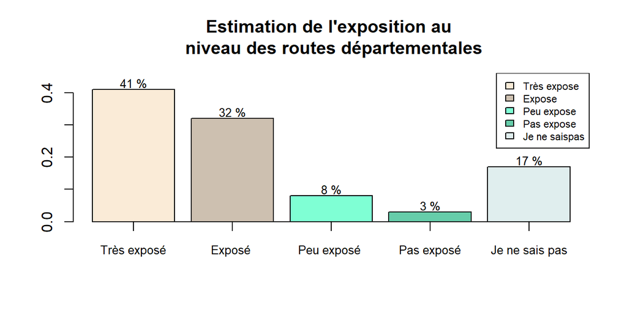

Toutefois, le sentiment s’exposition au niveau des ces routes n’affecte pas significativement le sentiment d’insécurité globale comme le montre la figure suivante.

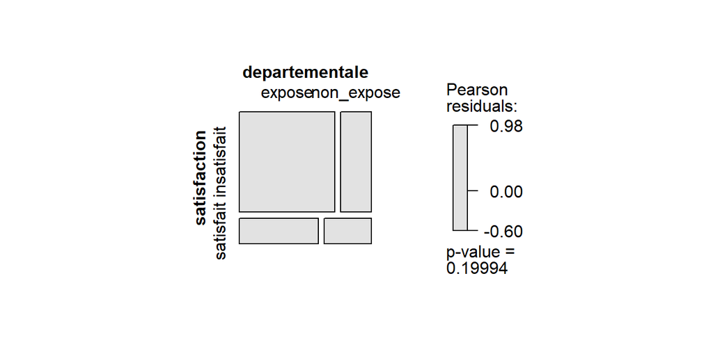

L’absence de lien entre l’insécurité routière et l’exposition au niveau des routes départementales pourrait être expliquée par le fait qu’ une majorité de cyclistes (ceux résidant dans l’aire urbaine de Caen) ne les emprunte pas. Ainsi, l’étude de la dépendance entre l’exposition au niveau des routes départementales et le sentiment d’insécurité routière selon la zone d’habitation pourrait donner un résultat différent comme le montre la figure suivante.

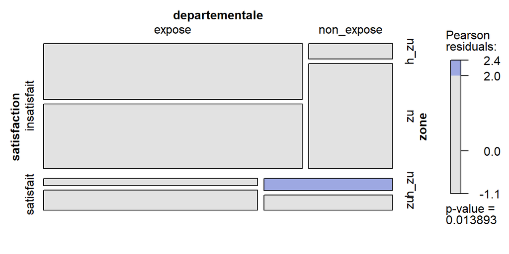

Ainsi, selon la zone de résidence, l’exposition au niveau des routes départementales impacte sur le sentiment global de sécurité. En effet, le sentiment d’être peu ou pas exposés au niveau des routes départementales pour les cyclistes issus de la zone hors aire urbaine de Caen est significativement associé à leur sentiment de sécurité en circulation alors que pour les cyclistes issus de l’aire urbaine de Caen, cette association est inexistente.

En conclusion, l’exposition au niveau de ces différents axes n’est pas significativement associée au sentiment d’insécurité des cyclistes. Par contre, la non exposition au niveau de ces axes améliore fortement la satisfaction des cyclistes en termes de sécurité routière.

Différents facteurs font que l’exposition ou non des cyclistes au niveau de ces axes reste déterminante sur leur sentiment global d’insécurité dans la circulation. L’accent sera mis sur les suivants: la vitesse ou le flux de circulation (noté vitesse), le manque de confiance du cycliste à l’égard de l’automobiliste (noté confiance), l’absence de séparation entre la chaussée et la piste cyclable (noté abs.sep).

```
## [1] "satisfait"   "insatisfait" "peu_satisf"
```

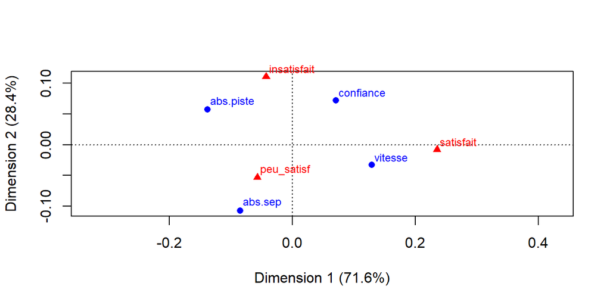

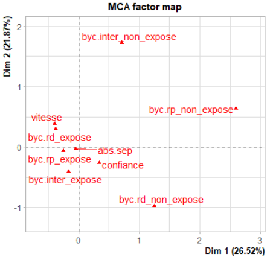

[output not shown]

## b- Courtoisie et confort

Comme la sécurité routière, le confort des trajets à vélo est crucial afin d’encourager l’usage du vélo.

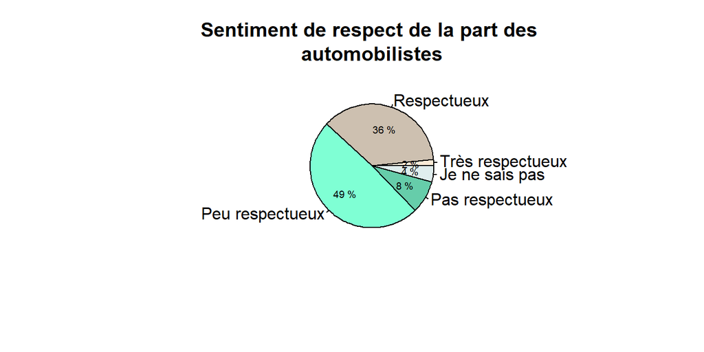

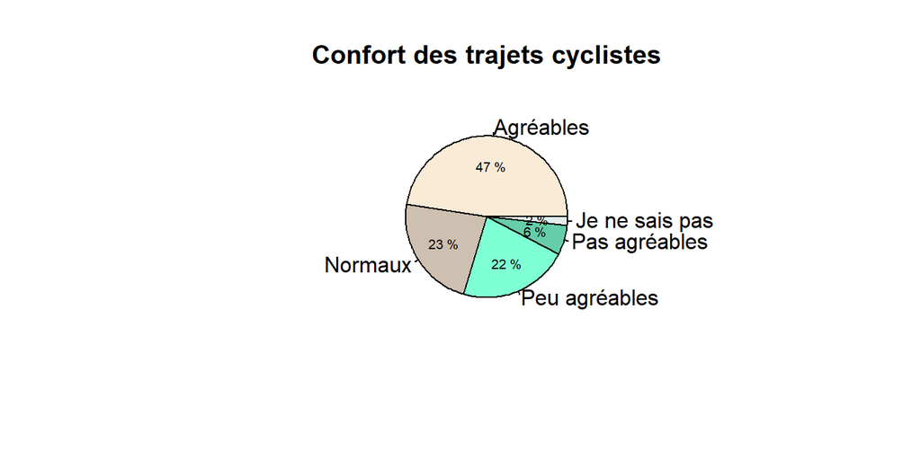

Alors que 57% des cyclistes considèrent le comportement des automobilistes à leur égard peu ou pas respectueux, 71% considère leurs trajets agréables ou normaux. En outre, le test de Cramer (dont la valeur est égale à 0.3205581) indique que l’agréabilité des trajets cyclistes est modéremment lié au comportement respectueux de la part des automobilistes. La figure suivante permet d’étudier comment le lien est établi entre ces deux variables.

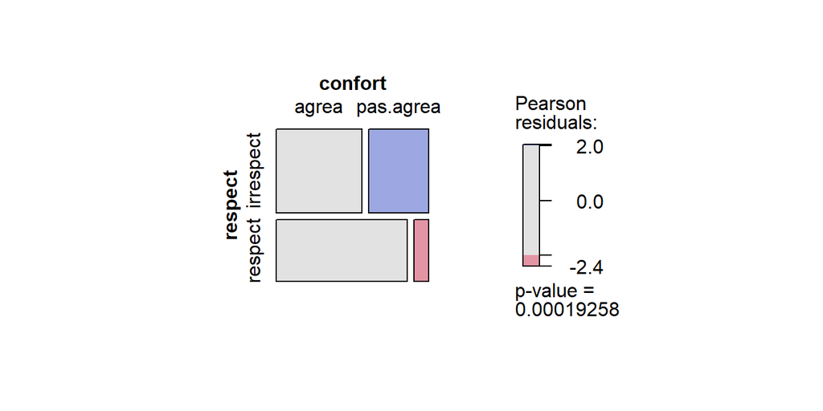

Certains faits de la part des automobilistes sont supposés comme les déterminants du comportement irres-pectueux des automobilistes. Il s’agit notamment des “queues de poisson”, des refus de priorité, les frôlement, les dépassements dangereux, les klaxons et les stationnements sur des pistes cyclables.

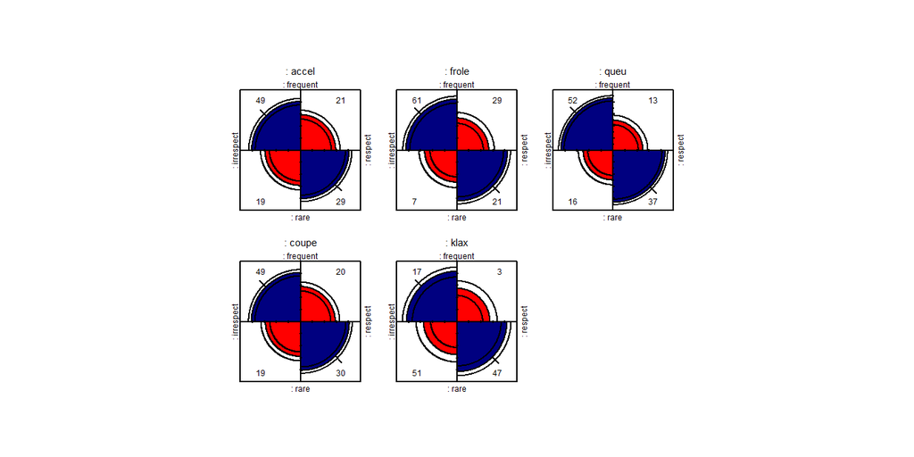

Chacun des quadrants représente le rapport de côte entre le sentiment de repect et d’irrespect qu’a le cycliste étant donné un supposé facteur. Ainsi, deux quadrants adjacents se supperposent si le rapport des côtes est égal à 1. C’est à dire? la probabilité que le cycliste considère le comportement de l’automobibiliste respecteux est égal à celle qu’il le considère irrespectueux. Pour chacun de ces différents supposés facteurs d’irrespect cités plus haut, la probabilité qu’il suscite un sentiment de manque de respect est plus élevée s’il est fréquent.

Outre, le comportement des automobilistes envers les cyclistes, le confort des trajets des cyclistes est aussi étudié selon la qualité du partage de certaines pistes avec les piétons, la fréquence de pistes discontinues ou étroites.

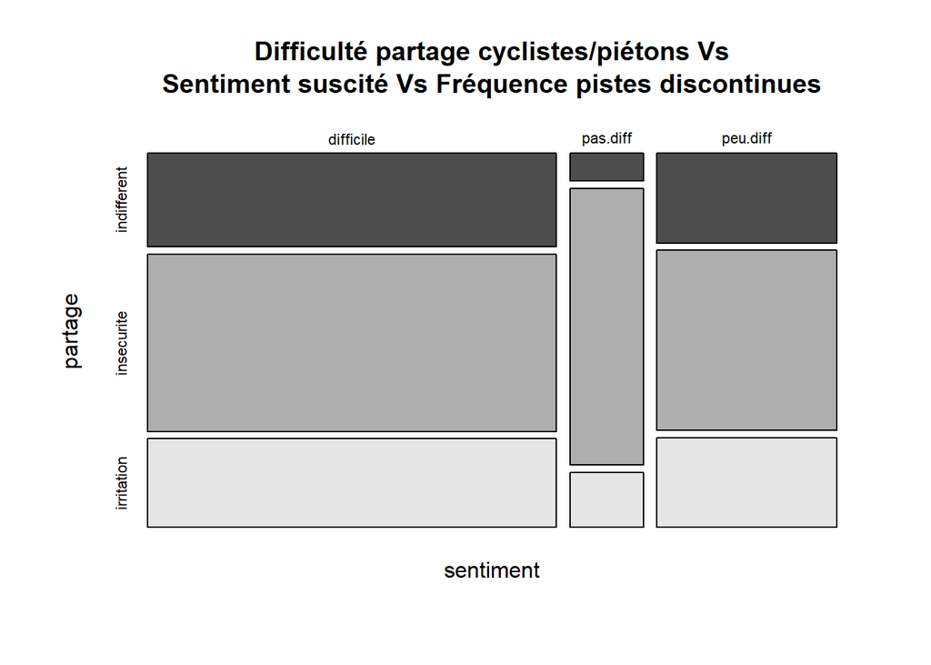

Une grande majorité des cyclistes pensent que le partage des aménagements cyclables avec les piétons est difficile, D’autre part, le sentiment d’“insécurité” au niveau des pistes étroites prévaut chez les cylclistes qui pensent comme tel.

L’analyse de ces aspects par rapport au confort des cyclistes avec une régression logistique indique que le sentiment d’insécurité sur les pistes étroites et la fréquences des pistes discontinues sont les plus de déterminants sur le confort des cyclistes.

La méthode de “la règle du pouce” et l’analyse des résidus de Pearson indiquent que ce modèle est pertinent,c’est à dire que le modèle est bien adpaté pour expliquer le confort des trajets cyclistes. En effet, la valeur correspondante à la “règle du pouce” est 1.11 (qui est donc sensiblement égal à 1) et la p-valeur des résidus de Pearson est de 0.63 (qui est largement supérieur au seuil de 0.05)

Ainsi, les “rapport des côtes”, pour chacune des variables, issue de ce modèle sont les suivants:

|  | x |
| --- | --- |
| (Intercept) | 1823.6219161 |
| insecurite | 0.3617045 |
| irrite | 0.9971370 |
| partage.pieton.L | 1.0496942 |
| partage.pieton.Q | 0.2143790 |
| discontinuite.L | 0.6377909 |
| discontinuite.Q | 0.0000015 |

Le rapport de côte ou risque relatif rapproché exprime le degré de dépendance entre deux variables qualitatives étudiées. Pour chacune des variables, si le rapport de côtes est supérieur à 1, alors l’augmentation de cette variable d’une unité augmente les chances que le cycliste trouve son trajet agréable. S’il est égal à 1, cette variable n’a aucun impact sur la réponse du cycliste. S’il est inférieur à 1, alors cette variable augmente les chances que le cycliste trouve son trajet désagréable.

Ainsi, les rapport de côtes ci-dessus indique que le sentiment d’insécurité sur les pistes cyclables étroites ainsi que la fréquence de discontinuité de ces dernières augmentent les chances que le trajet du cyliste soit désagréable.